# Chapter 4 Time series features

The feasts package includes functions for computing FEatures And Statistics from Time Series.

```r
library(fpp3)
library(feasts)
```

# 4.1 Some simple statistics

**Features** are numerical summmaries computed from a time series.`features()` is used in R for this purpose.

```r
tourism |>
  features(Trips, list(mean = mean, sd = sd)) |>
  arrange(mean)
```

| Region | State | Purpose | mean | sd |
| --- | --- | --- | --- | --- |
| Kangaroo Island | South Australia | Other | 0.3403467 | 0.8469782 |
| MacDonnell | Northern Territory | Other | 0.4490043 | 1.0040421 |
| Wilderness West | Tasmania | Other | 0.4782684 | 1.3478614 |
| Barkly | Northern Territory | Other | 0.6323856 | 1.3711961 |
| Clare Valley | South Australia | Other | 0.8977490 | 1.5349902 |
| Barossa | South Australia | Other | 1.0215210 | 1.7526117 |
| Kakadu Arnhem | Northern Territory | Other | 1.0426531 | 1.6602427 |
| Lasseter | Northern Territory | Other | 1.1357961 | 1.6875502 |
| Wimmera | Victoria | Other | 1.1462369 | 2.1926773 |
| MacDonnell | Northern Territory | Visiting | 1.1753932 | 1.6096421 |

[output cut: 294 more lines]

This shows that Kangaroo Island/Other had the least average number of visits.

Using `quantile` in the `features` argument of `features()` provides the basic statistical information.

```r
tourism |> features(Trips, quantile)
```

| Region | State | Purpose | 0% | 25% | 50% | 75% | 100% |
| --- | --- | --- | --- | --- | --- | --- | --- |
| Adelaide | South Australia | Business | 68.7253928 | 133.8934623 | 152.5766183 | 176.93553575 | 242.494368 |
| Adelaide | South Australia | Holiday | 108.0330401 | 134.6268221 | 153.9450073 | 172.25667650 | 223.557406 |
| Adelaide | South Australia | Other | 25.9018459 | 43.8659011 | 53.8094631 | 62.52313480 | 107.494657 |
| Adelaide | South Australia | Visiting | 136.6111544 | 178.9159984 | 205.5817356 | 229.29911105 | 269.535618 |
| Adelaide Hills | South Australia | Business | 0.0000000 | 0.0000000 | 1.2554337 | 3.92036845 | 28.601515 |
| Adelaide Hills | South Australia | Holiday | 0.0000000 | 5.7676731 | 8.5159661 | 14.05999700 | 35.751337 |
| Adelaide Hills | South Australia | Other | 0.0000000 | 0.0000000 | 0.9075955 | 2.09316670 | 8.953163 |
| Adelaide Hills | South Australia | Visiting | 0.7776381 | 8.9079230 | 12.2066190 | 16.80633948 | 81.102109 |
| Alice Springs | Northern Territory | Business | 1.0084255 | 9.1333689 | 13.3241614 | 18.45636535 | 34.077065 |
| Alice Springs | Northern Territory | Holiday | 2.8085551 | 16.8508033 | 31.5237822 | 44.78440207 | 76.541382 |

[output cut: 294 more lines]

# 4.2 ACF features

Autocorrelations were discussed in Section 2.8. All the autocorrelations of a series can be considered features of that series. We can also summarise the autocorrelations to produce new features; for example, the sum of the first ten squared autocorrelation coefficients is a useful summary of how much autocorrelation there is in a series, regardless of lag.

We can also compute autocorrelations of the changes in the series between periods. That is, we “difference” the data and create a new time series consisting of the differences between consecutive observations. Then we can compute the autocorrelations of this new differenced series. Occasionally reiteration of differencing may provide more useful information.

For example we may compute seasonal differences for monthly data, eg. Feb to Feb. This enables us to look at how the series is changing between years, rather than between months. Again, the autocorrelations of the seasonally differenced series may provide useful information.

The `feat_acf()` function computes a selection of the autocorrelations discussed here. It will return six or seven features:

- the first autocorrelation coefficient from the original data;
- the sum of squares of the first ten autocorrelation coefficients from the original data;
- the first autocorrelation coefficient from the differenced data;
- the sum of squares of the first ten autocorrelation coefficients from the differenced data;
- the first autocorrelation coefficient from the twice differenced data;
- the sum of squares of the first ten autocorrelation coefficients from the twice differenced data;
- For seasonal data, the autocorrelation coefficient at the first seasonal lag is also returned.

```r
tourism |> features(Trips, feat_acf)
```

| Region | State | Purpose | acf1 | acf10 | diff1_acf1 | diff1_acf10 | diff2_acf1 | diff2_acf10 | season_acf1 |
| --- | --- | --- | --- | --- | --- | --- | --- | --- | --- |
| Adelaide | South Australia | Business | 0.0332706975 | 0.13064555 | -0.51962239 | 0.4625367 | -0.6764291 | 0.7413571 | 0.2008754653 |
| Adelaide | South Australia | Holiday | 0.0455699797 | 0.37189807 | -0.34262507 | 0.6143649 | -0.4868330 | 0.5582436 | 0.3511513463 |
| Adelaide | South Australia | Other | 0.5168057344 | 1.15359755 | -0.40862039 | 0.3828913 | -0.6751196 | 0.7923533 | 0.3417806511 |
| Adelaide | South Australia | Visiting | 0.0683653639 | 0.29423657 | -0.39365431 | 0.4522912 | -0.5179591 | 0.4472958 | 0.3449304724 |
| Adelaide Hills | South Australia | Business | 0.0709149821 | 0.13447305 | -0.57950368 | 0.4145373 | -0.7504035 | 0.7460039 | -0.0628083736 |
| Adelaide Hills | South Australia | Holiday | 0.1313199901 | 0.31270988 | -0.53615349 | 0.5002113 | -0.7163426 | 0.9063143 | 0.2080420406 |
| Adelaide Hills | South Australia | Other | 0.2611425557 | 0.33016881 | -0.25322673 | 0.3170873 | -0.4574704 | 0.3922350 | 0.0745340896 |
| Adelaide Hills | South Australia | Visiting | 0.1391667389 | 0.11678659 | -0.47200585 | 0.2386155 | -0.6255751 | 0.4077128 | 0.1697721905 |
| Alice Springs | Northern Territory | Business | 0.2174243705 | 0.36663436 | -0.49958547 | 0.3805574 | -0.6579956 | 0.5870383 | 0.3153135650 |
| Alice Springs | Northern Territory | Holiday | -0.0066045107 | 2.11337425 | -0.15279046 | 2.1134358 | -0.2742857 | 1.5507370 | 0.7285888676 |

[output cut: 294 more lines]

# 4.3 STL features

The STL decomposition provides several more features. These can help identify the series with the most trend or seasonality among a large collection of time series.

For strongly trended data, the seasonally adjusted data should have much more variation than the remainder component. Therefore $Var(R_t)/Var(T_t+R_t)$ should be relatively small. But for data with little or no trend, the two variances should be approximately the same. So we define the **strength of trend** as:

$$F_T = \max\left(0, 1 -
\frac{\text{Var}(R_t)}{\text{Var}(T_t+R_t)}\right)$$
$F_T$ has a range of [0,1].

Similarly the **strength of seasonality** is

$$F_S = \max\left(0, 1 -
\frac{\text{Var}(R_t)}{\text{Var}(S_{t}+R_t)}\right)$$

```r
tourism |> features(Trips, feat_stl)
```

| Region | State | Purpose | trend_strength | seasonal_strength_year | seasonal_peak_year | seasonal_trough_year | spikiness | linearity | curvature | stl_e_acf1 | stl_e_acf10 |
| --- | --- | --- | --- | --- | --- | --- | --- | --- | --- | --- | --- |
| Adelaide | South Australia | Business | 0.4638070 | 0.40695852 | 3 | 1 | 1.584763e+02 | -5.31263324 | 71.5841775 | -0.5323114 | 0.5939747 |
| Adelaide | South Australia | Holiday | 0.5542186 | 0.61872915 | 1 | 2 | 9.167156e+00 | 49.04074774 | 78.7415934 | -0.5104023 | 0.5608486 |
| Adelaide | South Australia | Other | 0.7457291 | 0.20209161 | 2 | 1 | 2.097208e+00 | 95.08668021 | 43.3978084 | -0.3513377 | 0.4033702 |
| Adelaide | South Australia | Visiting | 0.4354986 | 0.45181536 | 1 | 3 | 5.612952e+01 | 34.57678790 | 71.3754529 | -0.5009820 | 1.0070351 |
| Adelaide Hills | South Australia | Business | 0.4641066 | 0.17939469 | 3 | 0 | 1.029723e-01 | 0.96847283 | -3.2189933 | -0.5998442 | 0.4966204 |
| Adelaide Hills | South Australia | Holiday | 0.5275212 | 0.29585432 | 2 | 1 | 1.766451e-01 | 10.46374827 | 23.9970281 | -0.4805950 | 0.3497724 |
| Adelaide Hills | South Australia | Other | 0.5934844 | 0.40387949 | 2 | 2 | 4.440051e-04 | 4.27725730 | 3.1857325 | -0.2975733 | 0.2814562 |
| Adelaide Hills | South Australia | Visiting | 0.4879478 | 0.25392506 | 0 | 3 | 6.497662e+00 | 34.22650625 | -0.5294727 | -0.4716180 | 0.4459566 |
| Alice Springs | Northern Territory | Business | 0.5339263 | 0.25101857 | 0 | 1 | 1.693929e-01 | 23.75862114 | 19.5455893 | -0.4916997 | 0.5479442 |
| Alice Springs | Northern Territory | Holiday | 0.3814929 | 0.83197830 | 3 | 1 | 7.385408e-01 | -19.59018961 | 10.5151806 | -0.5216814 | 0.7262383 |

[output cut: 294 more lines]

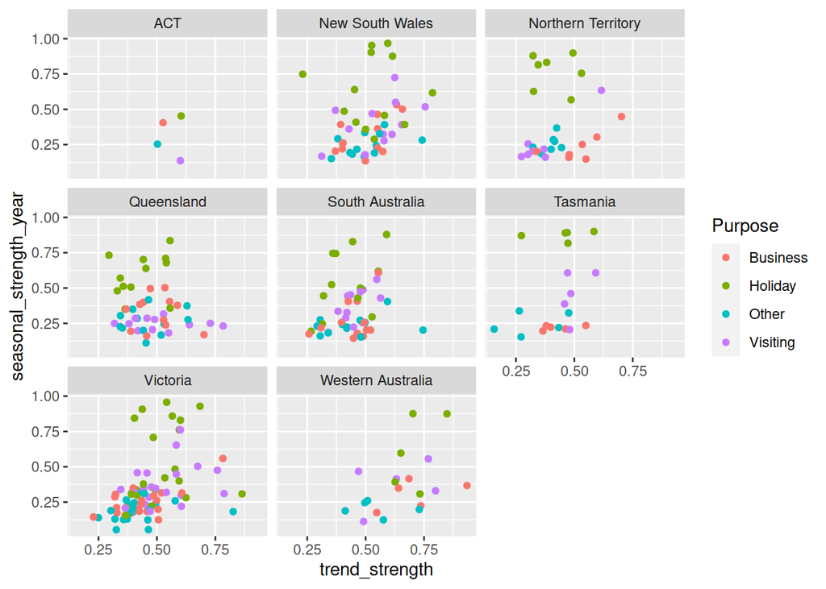

```r
tourism |>
  features(Trips, feat_stl) |>
  ggplot(aes(x = trend_strength,
             y = seasonal_strength_year,
             col = Purpose)) +
  geom_point() +
  facet_wrap(vars(State))
```

This shows strong seasonal strength for “Holiday” and strong trend strength for Victoria and Western Australia.

The most seasonal series can be easily identified and plotted.

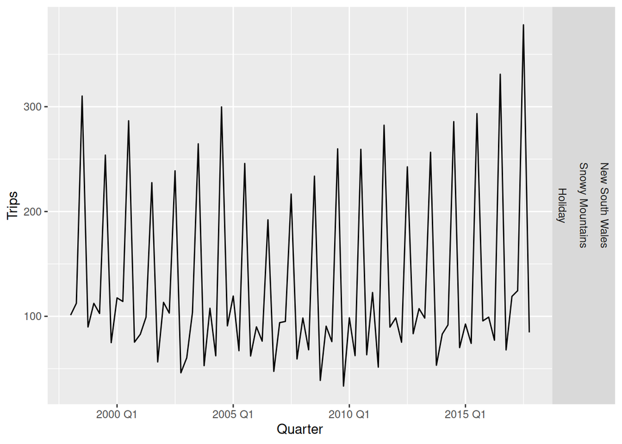

```r
tourism |>
  features(Trips, feat_stl) |>
  filter(
    seasonal_strength_year == max(seasonal_strength_year)
  ) |>
  left_join(tourism,
            by = c("State", "Region", "Purpose"),
            multiple = "all") |>
  ggplot(aes(x = Quarter, y = Trips)) +
  geom_line() +
  facet_grid(vars(State, Region, Purpose))
```

This is apparently the most popular ski region of Australia.

The `feat_stl()` function returns several more features other than those discussed above.

- `seasonal_peak_year` indicates the timing of the peaks — which month or quarter contains the largest seasonal component. This tells us something about the nature of the seasonality. In the Australian tourism data, if Quarter 3 is the peak seasonal period, then people are travelling to the region in winter, whereas a peak in Quarter 1 suggests that the region is more popular in summer.
- `seasonal_trough_year` indicates the timing of the troughs — which month or quarter contains the smallest seasonal component.
- `spikiness` measures the prevalence of spikes in the remainder component $R_t$ of the STL decomposition. It is the variance of the leave-one-out variances of $R_t$.
- `linearity` measures the linearity of the trend component of the STL decomposition. It is based on the coefficient of a linear regression applied to the trend component.
- `curvature` measures the curvature of the trend component of the STL decomposition. It is based on the coefficient from an orthogonal quadratic regression applied to the trend component.
- `stl_e_acf1` is the first autocorrelation coefficient of the remainder series.
- `stl_e_acf10` is the sum of squares of the first ten autocorrelation coefficients of the remainder series.

# 4.4 Other features of the `feasts` package

The remaining features in the feasts package, not previously discussed, are listed here for reference. The details of some of them are discussed later in the book.

- `coef_hurst` will calculate the Hurst coefficient of a time series which is a measure of **“long memory”**. A series with long memory will have significant autocorrelations for many lags.
- `feat_spectral` will compute the (Shannon) spectral entropy of a time series, which is a measure of **how easy the series is to forecast**. A series which has strong trend and seasonality (and so is easy to forecast) will have entropy close to 0. A series that is very noisy (and so is difficult to forecast) will have entropy close to 1.
- `box_pierce` gives the Box-Pierce statistic for testing if a time series is **white noise**, and the corresponding p-value. This test is discussed in Section 5.4.
- ljung_box gives the Ljung-Box statistic for testing if a time series is **white noise**, and the corresponding p-value. This test is discussed in Section 5.4.
- The $k$th partial autocorrelation measures the relationship between observations $k$ periods apart after removing the effects of observations between them. So the first partial autocorrelation ($k=1$) is identical to the first autocorrelation, because there is nothing between consecutive observations to remove. Partial autocorrelations are discussed in Section 9.5.
- The `feat_pacf` function contains several features involving partial autocorrelations including the sum of squares of the first five partial autocorrelations for the original series, the first-differenced series and the second-differenced series. For seasonal data, it also includes the partial autocorrelation at the first seasonal lag.
- `unitroot_kpss` gives the Kwiatkowski-Phillips-Schmidt-Shin (KPSS) statistic for **testing if a series is stationary**, and the corresponding p-value. This test is discussed in Section 9.1.
- unitroot_pp gives the Phillips-Perron statistic for testing if a **series is non-stationary**, and the corresponding p-value.
- `unitroot_ndiffs` gives the **number of differences required to lead to a stationary series** based on the KPSS test. This is discussed in Section 9.1
- `unitroot_nsdiffs` gives the **number of seasonal differences required to make a series stationary**. This is discussed in Section 9.1.
- `var_tiled_mean` gives the variances of the “tiled means” (i.e., the means of consecutive non-overlapping blocks of observations). The default tile length is either 10 (for non-seasonal data) or the length of the seasonal period. This is sometimes called the **“stability”** feature.
- `var_tiled_var` gives the variances of the “tiled variances” (i.e., the variances of consecutive non-overlapping blocks of observations). This is sometimes called the **“lumpiness”** feature.
- `shift_level_max` finds the largest mean shift between two consecutive sliding windows of the time series. This is useful for finding **sudden jumps or drops** in a time series.
- `shift_level_index` gives the index at which the largest mean shift occurs. shift_var_max finds the largest variance shift between two consecutive sliding windows of the time series. This is useful for finding **sudden changes in the volatility** of a time series.
- `shift_var_index` gives the index at which the largest variance shift occurs.
- `shift_kl_max` finds the largest distributional shift (based on the Kulback-Leibler divergence) between two consecutive sliding windows of the time series. This is useful for finding **sudden changes in the distribution** of a time series.
- `shift_kl_index` gives the index at which the largest KL shift occurs.
- `n_crossing_points` computes the number of times a time series crosses the median.
- `longest_flat_spot` computes the number of sections of the data where the series is relatively unchanging.
- `stat_arch_lm` returns the statistic based on the Lagrange Multiplier (LM) test of Engle (1982) for autoregressive conditional heteroscedasticity (ARCH).
- `guerrero` computes the optimal $\lambda$ value for a Box-Cox transformation using the Guerrero method (discussed in Section 3.1).

# 4.5 Exploring Australian tourism data

All of the features in the `feasts` package can be computed in one line.

```r
tourism_features <- tourism |>
  features(Trips, feature_set(pkgs = "feasts"))
tourism_features
```

| Region | State | Purpose | trend_strength | seasonal_strength_year | seasonal_peak_year | seasonal_trough_year | spikiness | linearity | curvature | stl_e_acf1 | stl_e_acf10 | acf1 | acf10 | diff1_acf1 | diff1_acf10 | diff2_acf1 | diff2_acf10 | season_acf1 | pacf5 | diff1_pacf5 | diff2_pacf5 | season_pacf | zero_run_mean | nonzero_squared_cv | zero_start_prop | zero_end_prop | lambda_guerrero | kpss_stat | kpss_pvalue | … |
| --- | --- | --- | --- | --- | --- | --- | --- | --- | --- | --- | --- | --- | --- | --- | --- | --- | --- | --- | --- | --- | --- | --- | --- | --- | --- | --- | --- | --- | --- | --- |
| Adelaide | South Australia | Business | 0.4638070 | 0.40695852 | 3 | 1 | 1.584763e+02 | -5.31263324 | 71.5841775 | -0.5323114 | 0.5939747 | 0.0332706975 | 0.13064555 | -0.51962239 | 0.4625367 | -0.6764291 | 0.7413571 | 0.2008754653 | 0.047928627 | 0.5603609 | 1.1300541 | 0.1957180918 | 0.000000 | 0.05253095 | 0.0000 | 0.0000 | 0.514261559 | 0.22097756 | 0.10000000 | … |
| Adelaide | South Australia | Holiday | 0.5542186 | 0.61872915 | 1 | 2 | 9.167156e+00 | 49.04074774 | 78.7415934 | -0.5104023 | 0.5608486 | 0.0455699797 | 0.37189807 | -0.34262507 | 0.6143649 | -0.4868330 | 0.5582436 | 0.3511513463 | 0.149852308 | 0.5379268 | 0.6975047 | 0.3294474902 | 0.000000 | 0.02988750 | 0.0000 | 0.0000 | -0.169464200 | 0.44856481 | 0.05622207 | … |
| Adelaide | South Australia | Other | 0.7457291 | 0.20209161 | 2 | 1 | 2.097208e+00 | 95.08668021 | 43.3978084 | -0.3513377 | 0.4033702 | 0.5168057344 | 1.15359755 | -0.40862039 | 0.3828913 | -0.6751196 | 0.7923533 | 0.3417806511 | 0.446731263 | 0.4758081 | 0.8503707 | 0.2946332072 | 0.000000 | 0.09398659 | 0.0000 | 0.0000 | -0.227127985 | 1.40621121 | 0.01000000 | … |
| Adelaide | South Australia | Visiting | 0.4354986 | 0.45181536 | 1 | 3 | 5.612952e+01 | 34.57678790 | 71.3754529 | -0.5009820 | 1.0070351 | 0.0683653639 | 0.29423657 | -0.39365431 | 0.4522912 | -0.5179591 | 0.4472958 | 0.3449304724 | 0.185622693 | 0.6306896 | 1.0003484 | 0.3140100451 | 0.000000 | 0.02508551 | 0.0000 | 0.0000 | 0.870273608 | 0.26365274 | 0.10000000 | … |
| Adelaide Hills | South Australia | Business | 0.4641066 | 0.17939469 | 3 | 0 | 1.029723e-01 | 0.96847283 | -3.2189933 | -0.5998442 | 0.4966204 | 0.0709149821 | 0.13447305 | -0.57950368 | 0.4145373 | -0.7504035 | 0.7460039 | -0.0628083736 | 0.075709246 | 0.4084429 | 1.0004127 | -0.1118632517 | 1.470588 | 1.48000233 | 0.0250 | 0.0125 | 0.124177951 | 0.05954492 | 0.10000000 | … |
| Adelaide Hills | South Australia | Holiday | 0.5275212 | 0.29585432 | 2 | 1 | 1.766451e-01 | 10.46374827 | 23.9970281 | -0.4805950 | 0.3497724 | 0.1313199901 | 0.31270988 | -0.53615349 | 0.5002113 | -0.7163426 | 0.9063143 | 0.2080420406 | 0.085064710 | 0.5166602 | 0.9414521 | 0.1807341862 | 1.000000 | 0.35292045 | 0.0000 | 0.0000 | 0.245753995 | 0.47640318 | 0.04698127 | … |
| Adelaide Hills | South Australia | Other | 0.5934844 | 0.40387949 | 2 | 2 | 4.440051e-04 | 4.27725730 | 3.1857325 | -0.2975733 | 0.2814562 | 0.2611425557 | 0.33016881 | -0.25322673 | 0.3170873 | -0.4574704 | 0.3922350 | 0.0745340896 | 0.110749767 | 0.3273449 | 0.5416476 | 0.0416748674 | 1.400000 | 0.75592619 | 0.0125 | 0.0000 | 0.364876281 | 0.60455196 | 0.02222255 | … |
| Adelaide Hills | South Australia | Visiting | 0.4879478 | 0.25392506 | 0 | 3 | 6.497662e+00 | 34.22650625 | -0.5294727 | -0.4716180 | 0.4459566 | 0.1391667389 | 0.11678659 | -0.47200585 | 0.2386155 | -0.6255751 | 0.4077128 | 0.1697721905 | 0.063316903 | 0.5077651 | 0.9525377 | 0.1308558832 | 0.000000 | 0.56573653 | 0.0000 | 0.0000 | 0.004143231 | 0.74943115 | 0.01000000 | … |
| Alice Springs | Northern Territory | Business | 0.5339263 | 0.25101857 | 0 | 1 | 1.693929e-01 | 23.75862114 | 19.5455893 | -0.4916997 | 0.5479442 | 0.2174243705 | 0.36663436 | -0.49958547 | 0.3805574 | -0.6579956 | 0.5870383 | 0.3153135650 | 0.157873896 | 0.5241717 | 0.9177545 | 0.2449116762 | 0.000000 | 0.24384812 | 0.0000 | 0.0000 | 0.561200578 | 0.80678573 | 0.01000000 | … |
| Alice Springs | Northern Territory | Holiday | 0.3814929 | 0.83197830 | 3 | 1 | 7.385408e-01 | -19.59018961 | 10.5151806 | -0.5216814 | 0.7262383 | -0.0066045107 | 2.11337425 | -0.15279046 | 2.1134358 | -0.2742857 | 1.5507370 | 0.7285888676 | 0.737791066 | 0.9784524 | 1.2138166 | 0.4951225685 | 0.000000 | 0.32286862 | 0.0000 | 0.0000 | 0.001744196 | 0.38729694 | 0.08263063 | … |

[output cut: 294 more lines]

This gives 48 features for every combination of the three key variables (`Region`, `State` and `Purpose`). We can treat this `tibble` like any data set and analyse it to find interesting observations or groups of observations.

We’ve already seen how we can plot one feature against another (Section 4.3). We can also do pairwise plots of groups of features. In Figure 4.3, for example, we show all features that involve seasonality, along with the `Purpose` variable.

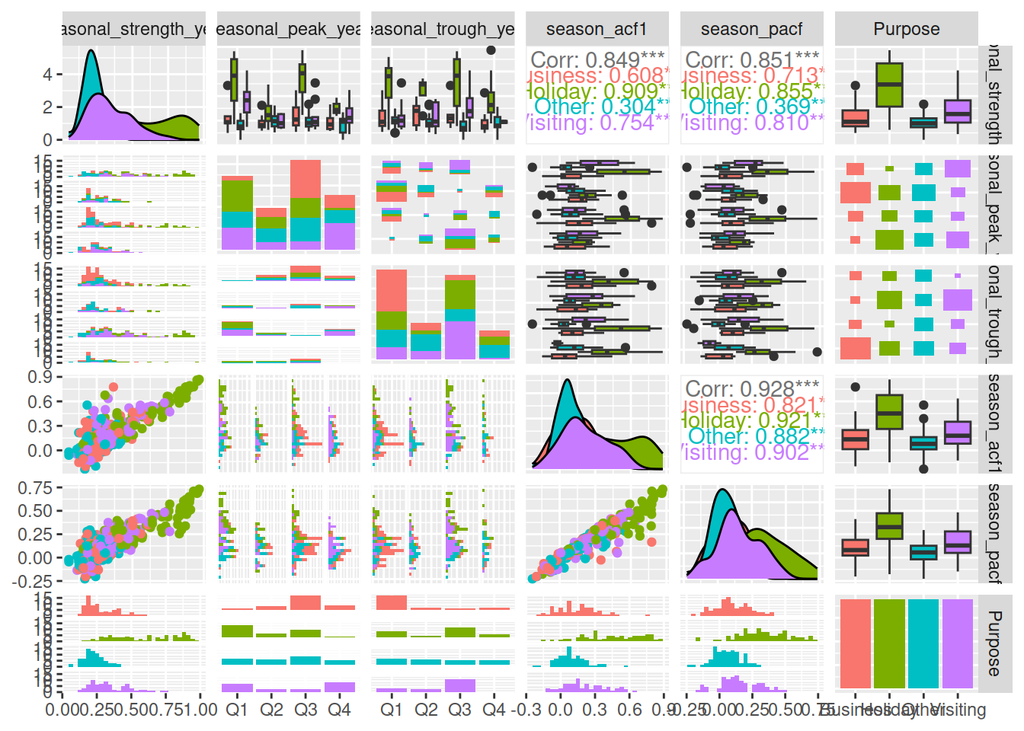

```r
library(glue)

tourism_features |>
  select_at(vars(contains("season"), Purpose)) |>
  mutate(
    seasonal_peak_year = seasonal_peak_year +
      4*(seasonal_peak_year == 0),
    seasonal_trough_year = seasonal_trough_year +
      4*(seasonal_trough_year == 0),
    seasonal_peak_year = glue("Q{seasonal_peak_year}"),
    seasonal_trough_year = glue("Q{seasonal_trough_year}"),
  ) |>
  GGally::ggpairs(mapping = aes(colour = Purpose))
```

It is difficult to explore more than a handful of variables in this way. A useful way to handle many more variables is to use a dimension reduction technique such as principal components. This gives linear combinations of variables that explain the most variation in the original data. We can compute the principal components of the tourism features as follows.

```r
library(broom)
pcs <- tourism_features |>
  select(-State, -Region, -Purpose) |>
  prcomp(scale = TRUE) |>
  augment(tourism_features)
pcs
```

| .rownames | Region | State | Purpose | trend_strength | seasonal_strength_year | seasonal_peak_year | seasonal_trough_year | spikiness | linearity | curvature | stl_e_acf1 | stl_e_acf10 | acf1 | acf10 | diff1_acf1 | diff1_acf10 | diff2_acf1 | diff2_acf10 | season_acf1 | pacf5 | diff1_pacf5 | diff2_pacf5 | season_pacf | zero_run_mean | nonzero_squared_cv | zero_start_prop | zero_end_prop | lambda_guerrero | kpss_stat | … |
| --- | --- | --- | --- | --- | --- | --- | --- | --- | --- | --- | --- | --- | --- | --- | --- | --- | --- | --- | --- | --- | --- | --- | --- | --- | --- | --- | --- | --- | --- | --- |
| 1 | Adelaide | South Australia | Business | 0.4638070 | 0.40695852 | 3 | 1 | 1.584763e+02 | -5.31263324 | 71.5841775 | -0.5323114 | 0.5939747 | 0.0332706975 | 0.13064555 | -0.51962239 | 0.4625367 | -0.6764291 | 0.7413571 | 0.2008754653 | 0.047928627 | 0.5603609 | 1.1300541 | 0.1957180918 | 0.000000 | 0.05253095 | 0.0000 | 0.0000 | 0.514261559 | 0.22097756 | … |
| 2 | Adelaide | South Australia | Holiday | 0.5542186 | 0.61872915 | 1 | 2 | 9.167156e+00 | 49.04074774 | 78.7415934 | -0.5104023 | 0.5608486 | 0.0455699797 | 0.37189807 | -0.34262507 | 0.6143649 | -0.4868330 | 0.5582436 | 0.3511513463 | 0.149852308 | 0.5379268 | 0.6975047 | 0.3294474902 | 0.000000 | 0.02988750 | 0.0000 | 0.0000 | -0.169464200 | 0.44856481 | … |
| 3 | Adelaide | South Australia | Other | 0.7457291 | 0.20209161 | 2 | 1 | 2.097208e+00 | 95.08668021 | 43.3978084 | -0.3513377 | 0.4033702 | 0.5168057344 | 1.15359755 | -0.40862039 | 0.3828913 | -0.6751196 | 0.7923533 | 0.3417806511 | 0.446731263 | 0.4758081 | 0.8503707 | 0.2946332072 | 0.000000 | 0.09398659 | 0.0000 | 0.0000 | -0.227127985 | 1.40621121 | … |
| 4 | Adelaide | South Australia | Visiting | 0.4354986 | 0.45181536 | 1 | 3 | 5.612952e+01 | 34.57678790 | 71.3754529 | -0.5009820 | 1.0070351 | 0.0683653639 | 0.29423657 | -0.39365431 | 0.4522912 | -0.5179591 | 0.4472958 | 0.3449304724 | 0.185622693 | 0.6306896 | 1.0003484 | 0.3140100451 | 0.000000 | 0.02508551 | 0.0000 | 0.0000 | 0.870273608 | 0.26365274 | … |
| 5 | Adelaide Hills | South Australia | Business | 0.4641066 | 0.17939469 | 3 | 0 | 1.029723e-01 | 0.96847283 | -3.2189933 | -0.5998442 | 0.4966204 | 0.0709149821 | 0.13447305 | -0.57950368 | 0.4145373 | -0.7504035 | 0.7460039 | -0.0628083736 | 0.075709246 | 0.4084429 | 1.0004127 | -0.1118632517 | 1.470588 | 1.48000233 | 0.0250 | 0.0125 | 0.124177951 | 0.05954492 | … |
| 6 | Adelaide Hills | South Australia | Holiday | 0.5275212 | 0.29585432 | 2 | 1 | 1.766451e-01 | 10.46374827 | 23.9970281 | -0.4805950 | 0.3497724 | 0.1313199901 | 0.31270988 | -0.53615349 | 0.5002113 | -0.7163426 | 0.9063143 | 0.2080420406 | 0.085064710 | 0.5166602 | 0.9414521 | 0.1807341862 | 1.000000 | 0.35292045 | 0.0000 | 0.0000 | 0.245753995 | 0.47640318 | … |
| 7 | Adelaide Hills | South Australia | Other | 0.5934844 | 0.40387949 | 2 | 2 | 4.440051e-04 | 4.27725730 | 3.1857325 | -0.2975733 | 0.2814562 | 0.2611425557 | 0.33016881 | -0.25322673 | 0.3170873 | -0.4574704 | 0.3922350 | 0.0745340896 | 0.110749767 | 0.3273449 | 0.5416476 | 0.0416748674 | 1.400000 | 0.75592619 | 0.0125 | 0.0000 | 0.364876281 | 0.60455196 | … |
| 8 | Adelaide Hills | South Australia | Visiting | 0.4879478 | 0.25392506 | 0 | 3 | 6.497662e+00 | 34.22650625 | -0.5294727 | -0.4716180 | 0.4459566 | 0.1391667389 | 0.11678659 | -0.47200585 | 0.2386155 | -0.6255751 | 0.4077128 | 0.1697721905 | 0.063316903 | 0.5077651 | 0.9525377 | 0.1308558832 | 0.000000 | 0.56573653 | 0.0000 | 0.0000 | 0.004143231 | 0.74943115 | … |
| 9 | Alice Springs | Northern Territory | Business | 0.5339263 | 0.25101857 | 0 | 1 | 1.693929e-01 | 23.75862114 | 19.5455893 | -0.4916997 | 0.5479442 | 0.2174243705 | 0.36663436 | -0.49958547 | 0.3805574 | -0.6579956 | 0.5870383 | 0.3153135650 | 0.157873896 | 0.5241717 | 0.9177545 | 0.2449116762 | 0.000000 | 0.24384812 | 0.0000 | 0.0000 | 0.561200578 | 0.80678573 | … |
| 10 | Alice Springs | Northern Territory | Holiday | 0.3814929 | 0.83197830 | 3 | 1 | 7.385408e-01 | -19.59018961 | 10.5151806 | -0.5216814 | 0.7262383 | -0.0066045107 | 2.11337425 | -0.15279046 | 2.1134358 | -0.2742857 | 1.5507370 | 0.7285888676 | 0.737791066 | 0.9784524 | 1.2138166 | 0.4951225685 | 0.000000 | 0.32286862 | 0.0000 | 0.0000 | 0.001744196 | 0.38729694 | … |

[output cut: 294 more lines]

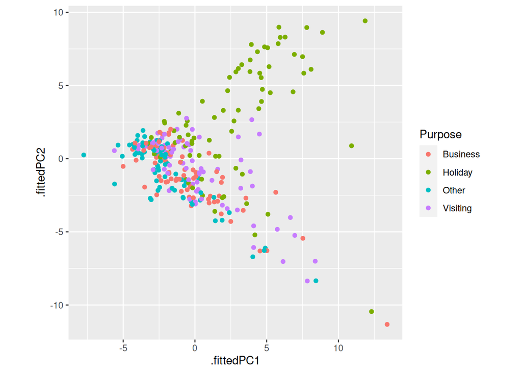

```r
pcs |>
  ggplot(aes(x = .fittedPC1,
             y = .fittedPC2,
             col = Purpose)) +
  geom_point() +
  theme(aspect.ratio = 1)
```

Each point on Figure 4.4 represents one series and its location on the plot is based on all 48 features. - `.fittedPC1` is the linear combination of the features which explains the most variation in the data. - `.fittedPC2` is the linear combination which explains the next most variation in the data - `.fittedPC2` is uncorrelated with `.fittedPC1`

Figure 4.4 reveals a few things about the tourism data. First, the holiday series behave quite differently from the rest of the series. Almost all of the holiday series appear in the top half of the plot, while almost all of the remaining series appear in the bottom half of the plot. Clearly, the second principal component is distinguishing between holidays and other types of travel.

The plot also allows us to identify anomalous time series — series which have unusual feature combinations. These appear as points that are separate from the majority of series in Figure 4.4. There are four that stand out, and we can identify which series they correspond to as follows.

```r
outliers <- pcs |>
  filter(.fittedPC1 > 10) |>
  select(Region, State, Purpose, .fittedPC1, .fittedPC2)
outliers
```

| Region | State | Purpose | .fittedPC1 | .fittedPC2 |
| --- | --- | --- | --- | --- |
| Australia's North West | Western Australia | Business | 13.39338 | -11.3229069 |
| Australia's South West | Western Australia | Holiday | 10.91327 | 0.8797467 |
| Melbourne | Victoria | Holiday | 12.30360 | -10.4479101 |
| South Coast | New South Wales | Holiday | 11.86105 | 9.4171279 |

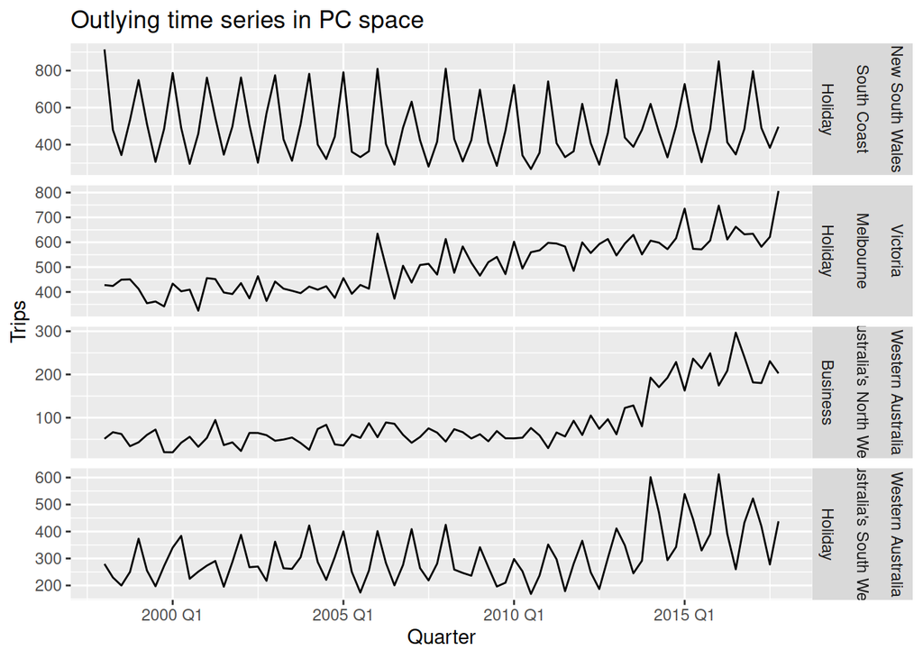

```r
outliers |>
  left_join(tourism,
            by = c("State", "Region", "Purpose"),
            multiple = "all") |>
  mutate(Series = glue("{State}", "{Region}", "{Purpose}",
                       .sep = "\n\n")) |>
  ggplot(aes(x = Quarter, y = Trips)) +
  geom_line() +
  facet_grid(Series ~ ., scales = "free") +
  labs(title = "Outlying time series in PC space")
```

- Holiday visits to the south coast of NSW is highly seasonal but has almost no trend, whereas most holiday destinations in Australia show some trend over time.
- Melbourne is an unusual holiday destination because it has almost no seasonality, whereas most holiday destinations in Australia have highly seasonal tourism.
- The north western corner of Western Australia is unusual because it shows an increase in business tourism in the last few years of data, but little or no seasonality.
- The south western corner of Western Australia is unusual because it shows both an increase in holiday tourism in the last few years of data and a high level of seasonality.